# Mountain yellow-legged frog (Rana muscosa) count in Sierra Nevada, California (1995 - 2002)

Mariano Viz

21/01/2021

### Summary

In this report, I explore the abundance of the mountain yellow-legged frog (Rana muscosa) in the Sierra Nevada ecosystem for the period 1995-2002. Specifically, I examine the total number of adult, subadult, and tadpole observed in the entire study region by year and the total counts of combined adult and subadult observed in the 5 lakes with the greatest total counts. Results are presented in a single compound figure. Data were extracted from Knapp et al. (2020).

```r
#Read in data (sierra_amphibians.xlsx)
amphibians_data <- read_excel(here("data", "sierra_amphibians.xlsx"))
```

```r
#Data wrangling: counts of Rana muscosa (RAMU) Adult, SubAdult, and Tadpole observed in the entire study region by year
ramu_counts_year <- amphibians_data %>%
  mutate(survey_date = ymd(survey_date)) %>% #convert $survey_date to class date
  mutate(survey_year = year(survey_date)) %>% #pull year to new col ($survey_year)
  filter(amphibian_species == "RAMU", amphibian_life_stage != "EggMass") %>%
  count(survey_year, amphibian_life_stage, wt = amphibian_number)


#Data Viz (stored to make a compound figure):
ramu_year_plot <- ggplot(data = ramu_counts_year, aes(x = survey_year, y = n)) +
  geom_col() +
  facet_wrap(~amphibian_life_stage, scales = "free")+
  scale_y_continuous(labels = scales::label_number_si())+
  scale_x_continuous(breaks=c(1995, 1996, 1997, 2000, 2001, 2002))+
  theme_minimal()+
  labs(x = "Year",
       title = "(A) Different life-stage counts by year")+
  theme(axis.text.x = element_text(angle = 90))
```

```r
#Data wrangling: total counts of Rana muscosa (RAMU) combined Adult and SubAdult and selection of the 5 lakes with the greatest total counts
ramu_counts_lake <- amphibians_data %>%
  filter(amphibian_species == "RAMU", amphibian_life_stage %in% c("Adult", "SubAdult")) %>%
  count(lake_id, wt = amphibian_number) %>%
  slice_max(n, n = 5) %>%
  mutate(lake_id = paste0('Lake ', lake_id)) %>%
  mutate(lake_id = fct_reorder(lake_id, n))


#Data Viz (stored to make a compound figure):
ramu_lake_plot <- ggplot(data = ramu_counts_lake, aes(x = lake_id, y = n)) +
  geom_col()+
  scale_y_continuous(labels = scales::comma)+
  theme_minimal()+
  labs(x = "Lake ID",
       title = "(B) Adult and Subadult counts by Lake")
```

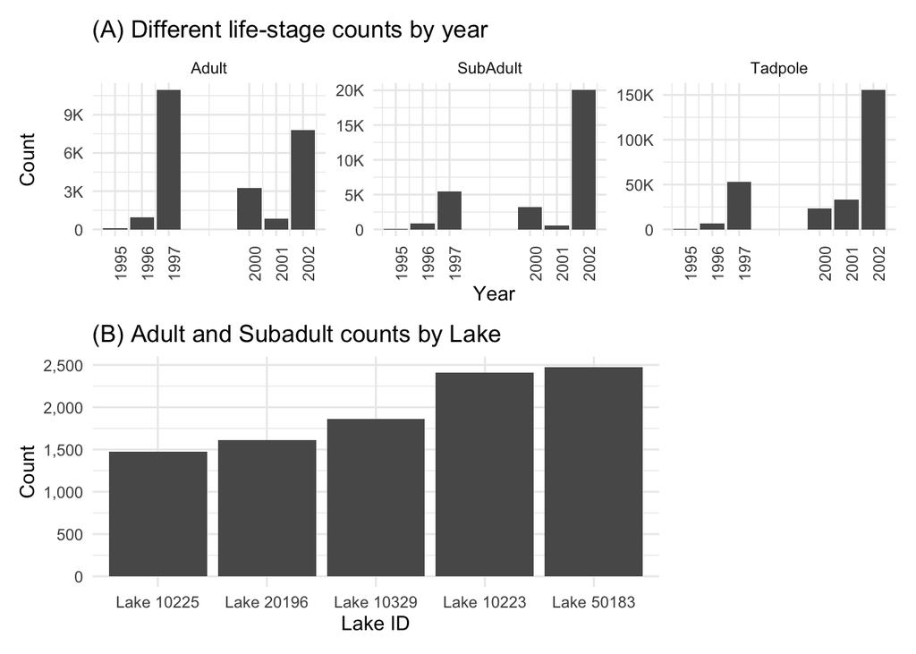

```r
#Compound figure (patchwork):
design <- "1111111
1111111
22222##
22222##
22222##"

ramu_year_plot / ramu_lake_plot + plot_layout(design = design) & labs(y = "Count")
```

**Figure 1.** Mountain yellow-legged frog (Rana muscosa) total number of adult, subadult, and tadpole observed in the entire study region by year (A) and total counts of combined adult and subadult observed in the 5 lakes with the greatest total counts (B). Data: Knapp et al. (2020).

### Citation

Knapp, R.A., C. Pavelka, E.E. Hegeman, and T.C. Smith. 2020. The Sierra Lakes Inventory Project: Non-Native fish and community composition of lakes and ponds in the Sierra Nevada, California ver 2. Environmental Data Initiative. https://doi.org/10.6073/pasta/d835832d7fd00d9e4466e44eea87fab3